# Tutorial 2: Building Toy Worlds (Interactive Notebook)

What a simulation is, and why scientists trust dice

## How to use this notebook

Open `ScienceHighSchool.Rproj` first. Run each code block with the green **Run** button, or place your cursor in the code and press **Cmd/Ctrl + Enter**.

Change one small thing at a time. Then run the block again and look at the result.

## Word list（単語リスト）

| English | 日本語 | Meaning |
| --- | --- | --- |
| simulation | シミュレーション | letting a model “run” inside a computer |
| model | モデル | a simplified copy of something real |
| probability | 確率 | how likely something is (0 = never, 1 = always) |
| loop | ループ・繰り返し | telling R to repeat something many times |
| random walk | ランダムウォーク | a path built from random steps |

## What is a model?

A map of Tokyo is not Tokyo. It leaves out almost everything — and that’s exactly why it is useful.

A **model** is the same idea in science: a simplified copy of the real world that keeps only the parts we care about. A **simulation** is what happens when we let a model run inside a computer, like pressing “play”.

This week our models will be about **people (and animals) learning and copying each other**. But first, let’s build the simplest possible toy world.

## Experiment 1: How fair is a coin?

If you flip a fair coin 10 times, do you get exactly 5 heads?

```r
flips <- sample(c(1, 0), size = 10, replace = TRUE)  # 1 = heads, 0 = tails
flips
```

```
 [1] 0 0 0 1 1 1 0 1 0 1
```

```r
sum(flips)   # how many heads?
```

```
[1] 5
```

```r
flips <- sample(c(1, 0), size = 10, replace = TRUE)  # 1 = heads, 0 = tails
flips
```

```
 [1] 1 1 1 1 1 0 0 1 1 0
```

```r
sum(flips)   # how many heads?
```

```
[1] 7
```

Run this a few times. Sometimes 3 heads, sometimes 7… Now the magic of simulation: **we don’t have to flip by hand.**

```r
n_heads <- replicate(10000, sum(sample(c(1, 0), size = 10, replace = TRUE)))
```

`replicate(10000, ...)` repeats our little experiment **ten thousand times** and collects the results. Let’s see them all:

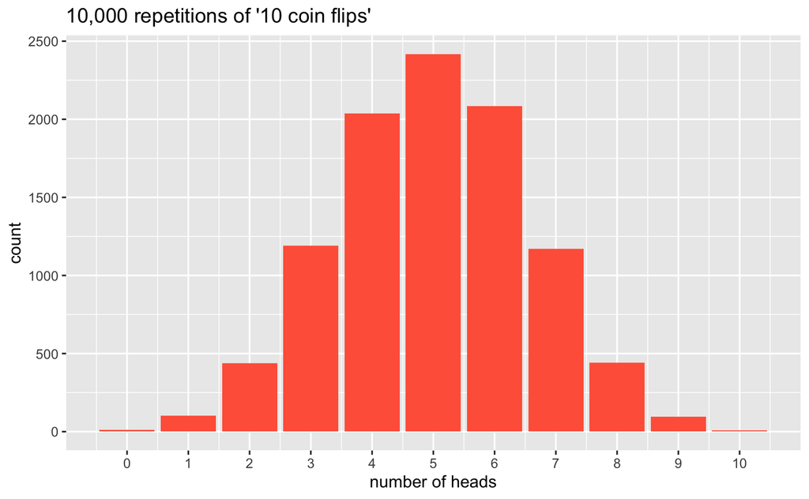

```r
library(ggplot2)
ggplot(data.frame(n_heads), aes(x = n_heads)) +
  geom_bar(fill = "tomato") +
  scale_x_continuous(breaks = 0:10) +
  labs(title = "10,000 repetitions of '10 coin flips'",
       x = "number of heads", y = "count")
```

## Try it! — how surprising is 9 heads?

Using the vector `n_heads`:

```r
mean(n_heads >= 9)
```

This computes the fraction of experiments with 9 or 10 heads. If a friend flips 10 coins and gets 9 heads, should you suspect a trick coin?

*(This — estimating a probability by simulating many times — is called the **Monte Carlo method**. Real researchers use it constantly.)*

## Experiment 2: More flips, more truth

```r
flip_average <- function(n_flips) {
  mean(sample(c(1, 0), size = n_flips, replace = TRUE))
}

results <- data.frame(
  n = c(10, 100, 1000, 10000),
  proportion_heads = c(flip_average(10), flip_average(100),
                       flip_average(1000), flip_average(10000))
)
results
```

| n | proportion_heads |
| --- | --- |
| 10 | 0.5000 |
| 100 | 0.4700 |
| 1000 | 0.4890 |
| 10000 | 0.5119 |

Small samples are wild; big samples settle near 0.5. This is the **law of large numbers** — and it is one reason why *averaging many opinions* can be powerful. Remember this for Day 3: it is the secret behind the “wisdom of crowds”.

## Writing our own function

We just did something important: we wrote our **own function**, `flip_average()`. A function is a recipe:

```r
name <- function(ingredients) {
  ... what to do ...
}
```

From now on we will build all our models as functions.

## Experiment 3: The random walk

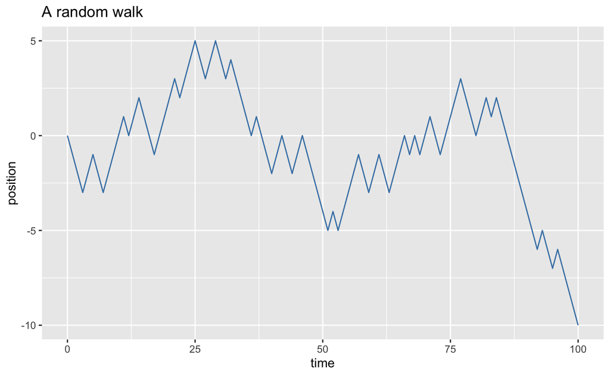

```r
steps <- sample(c(1, -1), size = 100, replace = TRUE)
position <- c(0, cumsum(steps))   # cumulative sum: position after each step
ggplot(data.frame(time = 0:100, position), aes(time, position)) +
  geom_line(color = "steelblue") +
  labs(title = "A random walk")
```

Run it again — a completely different path every time! Now let’s watch **20 walkers at once**:

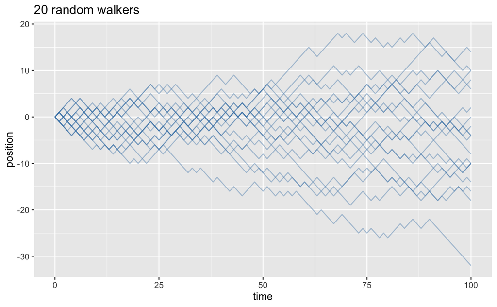

```r
random_walk <- function(n_steps = 100) {
  c(0, cumsum(sample(c(1, -1), size = n_steps, replace = TRUE)))
}

walks <- data.frame(
  time = rep(0:100, times = 20),
  position = unlist(lapply(1:20, function(i) random_walk(100))),
  walker = rep(1:20, each = 101)
)

ggplot(walks, aes(time, position, group = walker)) +
  geom_line(alpha = 0.4, color = "steelblue") +
  labs(title = "20 random walkers")
```

Each walker is different, but the *crowd* of walkers has a clear shape: it spreads out like a fan. **Individual randomness, collective pattern.** That is the core idea of everything we do this week.

## Try it! — biased walkers

1. Change the walk so that steps are `+1` with probability 0.6 and `-1` with probability 0.4 (hint: `prob = c(0.6, 0.4)` inside `sample()`).
2. Plot 20 of these walkers. What changed about the fan?
3. A stock price, a drunk person, an animal searching for food — which of these could a random walk be a model of? What does the model *leave out* in each case?

## What you learned

- A **model** is a deliberately simplified toy world; a **simulation** runs it
- `replicate()` and functions let us repeat experiments thousands of times
- Small samples lie; large samples tell the truth (law of large numbers)
- Simple random rules can create clear collective patterns

Next tutorial: our toy world gets its first **inhabitant** — an agent that can *learn*.